# PyMC3: Challenger Disaster

Patrick Ho

2019-03-24

Source

```python
import pymc3 as pm
import theano.tensor as tt
import pandas as pd
import numpy as np
from scipy.stats.mstats import mquantiles
import matplotlib.pyplot as plt
plt.style.use('seaborn')

%matplotlib inline
```

### Load and prep data

```python
df = pd.read_csv('./data/challenger_data.csv')

df = df.drop(['Date'], axis=1)
df['Damage Incident'] = pd.to_numeric(df['Damage Incident'], errors='coerce')
df = df[df['Damage Incident'].notnull()]

print('Temp (F), O-Ring Failure?')
df
```

```
Temp (F), O-Ring Failure?
```

|  | Temperature | Damage Incident |
| --- | --- | --- |
| 0 | 66 | 0.0 |
| 1 | 70 | 1.0 |
| 2 | 69 | 0.0 |
| 4 | 68 | 0.0 |
| 5 | 67 | 0.0 |
| 6 | 72 | 0.0 |
| 7 | 73 | 0.0 |
| 8 | 70 | 0.0 |
| 9 | 57 | 1.0 |
| 10 | 63 | 1.0 |
| 11 | 70 | 1.0 |
| 12 | 78 | 0.0 |
| 13 | 67 | 0.0 |
| 14 | 53 | 1.0 |
| 15 | 67 | 0.0 |
| 16 | 75 | 0.0 |
| 17 | 70 | 0.0 |
| 18 | 81 | 0.0 |
| 19 | 76 | 0.0 |
| 20 | 79 | 0.0 |
| 21 | 75 | 1.0 |
| 22 | 76 | 0.0 |
| 23 | 58 | 1.0 |

### Define model

Explore the data and create a model for the actual underlying system

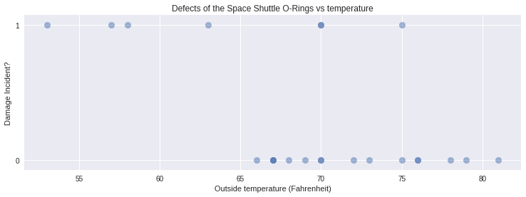

```python
plt.figure(figsize=(12.5, 4))

plt.scatter(df['Temperature'], df['Damage Incident'], s=75, alpha=0.5)
plt.yticks([0, 1])
plt.ylabel("Damage Incident?")
plt.xlabel("Outside temperature (Fahrenheit)")
plt.title("Defects of the Space Shuttle O-Rings vs temperature");
```

Damage incident appears to be more likely at lower temperatures.

Aim is to model probability of damage at different temperatures, $P(t)$. Can use the logistic function for this:

$$P(t)=\frac{1}{1+e^{-\beta t+\alpha}}$$

where $\beta$ controls the slope and $\alpha$ shifts curve left/right (bias)

```python
temperature = df['Temperature']
damaged = df['Damage Incident']

with pm.Model() as model:

    # Priors
    # Init both to 0 so P(t) has a reasonable starting value at 0.5
    beta = pm.Normal('beta', mu=0, sd=1000, testval=0)
    alpha = pm.Normal('alpha', mu=0, sd=1000, testval=0)

    # P(t) assumed to follow logistic function
    # Use Theano exp() to build this as compute graph
    p = pm.Deterministic('p', 1.0/(1.0 + tt.exp(-beta*temperature + alpha)))

    # Observed
    obs = pm.Bernoulli('obs', p, observed=damaged)

    # Sample
    step = pm.Metropolis()
    trace = pm.sample(120000, step=step, start=start)
    burned_trace = trace[100000::2]
```

```
Multiprocess sampling (2 chains in 2 jobs)
CompoundStep
>Metropolis: [alpha]
>Metropolis: [beta]
The estimated number of effective samples is smaller than 200 for some parameters.
```

```python
alpha_samples = burned_trace['alpha']
beta_samples = burned_trace['beta']
```

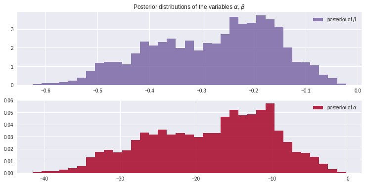

```python
plt.figure(figsize=(12.5, 6))

plt.subplot(211)
plt.title(r"Posterior distributions of the variables $\alpha, \beta$")
plt.hist(beta_samples, histtype='stepfilled', bins=35, alpha=0.85,
         label=r"posterior of $\beta$", color="#7A68A6", density=True)
plt.legend()

plt.subplot(212)
plt.hist(alpha_samples, histtype='stepfilled', bins=35, alpha=0.85,
         label=r"posterior of $\alpha$", color="#A60628", density=True)
plt.legend();
```

$\beta$ samples are <0:

- Does not centre around 0, which would have implied no effect (no slope)
- Negative means $P(t)$ increases as $t$ decreases

### Inspect model

```python
def logistic(x, beta=1, alpha=0):
    return 1.0 / (1.0 + np.exp(np.dot(-beta, x) + alpha))
```

```python
t_min = temperature.min()-5
t_max = temperature.max()+5
t_step = t_max-t_min+1

# Reshape from arrays to 1-D matrices to enable vector maths
t = np.linspace(t_min, t_max, t_step).reshape(-1,1)
beta_samples_1d = beta_samples.reshape(-1,1)
alpha_samples_1d = alpha_samples.reshape(-1,1)

print(beta_samples_1d.shape, t.T.shape, alpha_samples_1d.shape)

p_t = logistic(t.T, beta_samples_1d, alpha_samples_1d)

print(p_t.shape)

mean_p_t = p_t.mean(axis=0)
```

```
(20000, 1) (1, 39) (20000, 1)
(20000, 39)
```

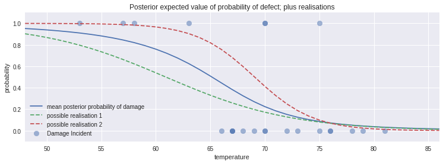

```python
plt.figure(figsize=(12.5, 4))

# Observed points
plt.scatter(temperature, damaged, s=75, alpha=0.5)

# Mean posterior
plt.plot(t, mean_p_t, label='mean posterior probability of damage')

# A couple of possible realisations from the posterior
plt.plot(t, p_t[0,:], ls='--', label='possible realisation 1')
plt.plot(t, p_t[-1,:], ls='--', label='possible realisation 2')

# Formatting
plt.xlim(t.min(), t.max())
plt.xlabel("temperature")
plt.ylim(-0.1, 1.1)
plt.ylabel("probability")
plt.legend(loc="lower left")
plt.title("Posterior expected value of probability of defect; \
plus realisations");
```

The dotted lines are just possible realisations of what the actual underlying system might be and are equally likely as any other draw. The solid line is the average of all 20000 possible dotted lines together.

##### 95% Credible Intervals

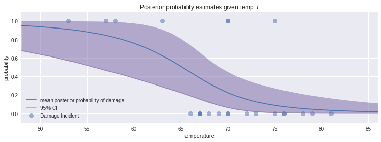

```python
plt.figure(figsize=(12.5, 4))

# Observed points
plt.scatter(temperature, damaged, s=75, alpha=0.5)

# Mean posterior
plt.plot(t, mean_p_t, label='mean posterior probability of damage')

# 95% Credible Interval
qs = mquantiles(p_t, [0.025, 0.975], axis=0)
plt.fill_between(t.reshape(-1), y1=qs[0], y2=qs[1],
                 color="#7A68A6", alpha=0.5)
plt.plot(t.reshape(-1), qs[0], label="95% CI",
         color="#7A68A6", alpha=0.5)

# Formatting
plt.xlim(t.min(), t.max())
plt.xlabel("temperature")
plt.ylim(-0.1, 1.1)
plt.ylabel("probability")
plt.legend(loc="lower left")
plt.title('Posterior probability estimates given temp. $t$');
```

Credible interval is widest around 60-65 degrees so we are most uncertain about the estimates here. Suggest gathering more data around here to improve estimates.

##### Day of Challenger disaster

Temperature was 31 degrees F. Under these conditions the model suggests that damage was almost guaranteed.

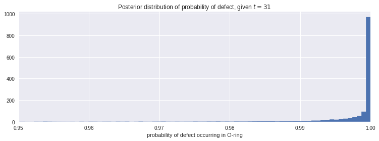

```python
plt.figure(figsize=(12.5, 4))

prob_31 = logistic(31, beta_samples, alpha_samples)

plt.xlim(0.95, 1)
plt.hist(prob_31, bins=1000, density=True, histtype='stepfilled')
plt.title("Posterior distribution of probability of defect, given $t = 31$")
plt.xlabel("probability of defect occurring in O-ring");
```

Reference: https://github.com/CamDavidsonPilon/Probabilistic-Programming-and-Bayesian-Methods-for-Hackers